# SIR temptative model

Angela Carraro, Giullia Monteiro Milano Oliveira, Gaia Saveri

3/07/2020

```r
library(readr)
library(rstan)
library(dplyr)
library(ggplot2)
library(bayesplot)
library(lubridate)
```

## The SIR model

The SIR model (which is an acronym for Susceptible, Infected, Recovered or Removed) is a *population-based* model, which subdivide the population into homogeneous time-dependent groups, called *compartments*. The flows between compartments can be described by a system of ODEs.

The temporal dynamic of the sizes of each of the compartmnerts are governed by the following system of ODEs:

$$\frac{dS}{dt} = -\beta\cdot S \cdot \frac{I}{N} \\
\frac{dI}{dt} = \beta \cdot S \cdot \frac{I}{N} - \gamma\cdot I \\
\frac{dR}{dt} = \gamma\cdot I$$

where $S(t)$ is the number of people suscptible to becoming infected, $I(t)$ is the number of people currently infected, $R(t)$ is the number of people that are recovered or removed (dead).

The $\beta$ is called *effective contact rate* and controls the rate of spread which represents the probability of transmitting disease between a susceptible and an infectious individual.

The $\gamma$ is called *recoverity and mortality* rate and it is determined by the average duration of infection.

Assumption behind this model are that:

- $N=S+I+R$ remains constant, namely births and deaths (except the ones due to the disease) are not contributing to the dynamics;
- recovered individual cannot be susceptible again (full immunity);
- infection rate and recovery rate are constant;
- individuals meet any other individual uniformely at random and recovery time follows an exponential distribution woth mean $\frac{1}{\gamma}$.

Basically we have that the disease enters the susceptible population, reduces its size by infecting a fraction of people and the infected fraction is reduced by the fraction of individuals who recover (or die) from the disease.

This is the mathematical framework of the SIR model, now we need to give it a statistical formulation.

## Statistical model

Let’s start by the likelihood, also called *sampling distribution* $p(Y|\theta)$ which tells us, given the parameters, how to generate the data. We want to link the solution we get from the ODEs to the observed data. Let’s say that $\hat{I}(t)$ are the number of infected people at time $t$ as predictedd by the SIR model, while $I(t)$ is the number of observed infected people at time $t$ (comfirmed cases as given by our data).

As we proposed in other models (the class of glm) we can model the number of infected people with a count distribution, such as the Negative Binomial, having $\hat{I}(t)$ as expected value and a parameter $\phi$ that allows for overdispersion.

$$I(t) \sim \mathcal{NagativeBinomial}(\hat{I}(t), \phi)$$

With this model, the set of parameters we have to deal with now is $\theta = (\beta, \gamma, \phi)$.

Being our model a Bayesian one, we need to put a prior (which encodes the information about the parameters we have before observing the data) over these parameters, $p(\theta)$.

$$\beta \sim \mathcal{LogNormal}(log(0.4),0.5) \\
\gamma \sim \mathcal{LogNormal}(log(0.1), 0.2) \\
\frac{1}{\phi} \sim \mathcal{Exp}(5)$$

Having the likelihood and the prior, we are at this point ready to apply Bayes theorem to estimate the posterior $p(\theta|Y) \propto p(Y|theta)\cdot p(\theta)$, by fitting the model.

Then we can compute a posterior distribution of predictions $p(Y_{pred}|Y) = \int p(Y_{pred}|\theta)p(\theta|Y)d\theta$.

A very famous and important qauntity that depends on the model parameters, hence we can compute, is the basic reproduction number $R_0$, defined as the expected number of secondary infections produced from one infected individual in a fully susceptible population through the entire duration of the infectious period.

By means of Bayesian inference we can build a posterior for $R_0$, that being $p(R_0|Y)$.

## Building the model

Guess what.. need to fix the data!

```r
data<-read_csv("data/SIR_data.csv")
data<- data %>% select(-X1)
data<-data[,c(1,3,2)]
missing.data<-read_csv("data/dead_recovered.csv")
missing.data<-missing.data %>% select(-"confirmed")
missing.data<-missing.data %>% select(-"confirmed_daily")
missing.data<-missing.data[-1,]
missing.data<-missing.data[-c(2,3,5),]
deaths<-missing.data$deaths
recovered<-missing.data$recovered

data$`cumulative_deaths`<-deaths
data$`cumulative_recoveries`<-recovered
#pop in millions
bogotà_pop<-7.4
antioquia_pop<-6.4
cundimarca_pop<-2.9
caldas_pop<-0.99
valle_cauca_pop<-4.4
meta_pop<-1
risaralda_pop<-0.94
santander_pop<-2.1
quindio_pop<-0.53
tolima_pop<-1.3
cauca_pop<-1.4
casanare_pop<-0.42
boyaca_pop<-1.2

tot_pop<-N<-7.4+6.4+2.9+0.99+4.4+1+0.94+2.1+0.53+1.3+1.4+0.42+1.2
N<-N*10^6 #from millions to individuals
```

We can compute the S-I-R quantities we need as follows:

- S := Susceptible = All - Confirmed;
- I := Infected = Confirmed - Recovered - Deaths;
- R := Recovered or fatal = Recovered + Deaths.

```r
All<-as.vector(rep(N,25))
data$S<-All-data$y
data$I<-data$y-data$cumulative_deaths-data$cumulative_recoveries
data$R<-data$cumulative_deaths+data$cumulative_recoveries

SIR.data<-data[,c(2,3,6,7,8)]


y_new<-c(1,as.vector(SIR.data$y[2:nrow(SIR.data)])-as.vector(SIR.data$y[1:nrow(SIR.data)-1]))
SIR.data$y_new<-y_new
SIR.data<-SIR.data[,c(1,2,6,3,4,5)]

head(SIR.data)
```

```
## # A tibble: 6 x 6
##   elapsed_time     y y_new        S     I     R
##          <dbl> <dbl> <dbl>    <dbl> <dbl> <dbl>
## 1            0     1     1 30979999     1     0
## 2            3     3     2 30979997     3     0
## 3            5     9     6 30979991     9     0
## 4            6    11     2 30979989    11     0
## 5            7    16     5 30979984    16     0
## 6            8    24     8 30979976    24     0
```

Let’s fix things up to fix the stan model:

```r
cases<-SIR.data$y
n_days<-length(cases)
t<-seq(0, n_days, by=1)
#I.C. for the ODEs
t0<-0
t<-t[-1]
i0<-1
s0<-N-i0
r0<-0
y0 = c(S=s0, I=i0, R=r0)

Sir.data<-list(n_days = n_days,
               y0 = y0,
               t0 = t0,
               ts = t,
               N = N,
               cases = cases)

#compile the model
Sir.model<-stan_model("stan/SIR.stan")
```

[output not shown]

```r
#run the model
fit.model<-sampling(Sir.model, data=Sir.data)
```

Let’s check the correctness of the inference of the model:

```r
pars<-c("beta", "gamma", "R0", "recovery_time")
print(fit.model, pars=pars)
```

```
## Inference for Stan model: SIR.
## 4 chains, each with iter=2000; warmup=1000; thin=1;
## post-warmup draws per chain=1000, total post-warmup draws=4000.
##
##                mean se_mean     sd 2.5%  25%  50%  75% 97.5% n_eff Rhat
## beta           0.63    0.00   0.15 0.39 0.51 0.62 0.75  0.93   987 1.01
## gamma          0.26    0.00   0.15 0.02 0.14 0.25 0.37  0.57   970 1.01
## R0             8.68    3.59 112.57 1.65 2.00 2.49 3.58 20.50   983 1.00
## recovery_time 20.77    9.77 306.03 1.77 2.69 4.03 6.92 52.15   982 1.00
##
## Samples were drawn using NUTS(diag_e) at Wed Jul  1 17:10:36 2020.
## For each parameter, n_eff is a crude measure of effective sample size,
## and Rhat is the potential scale reduction factor on split chains (at
## convergence, Rhat=1).
```

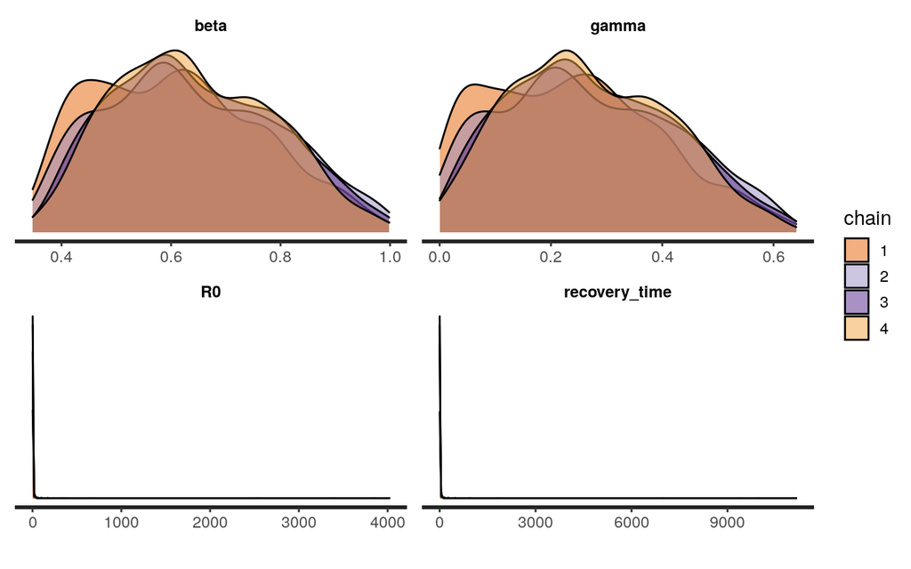

```r
stan_dens(fit.model, pars=pars, separate_chains=TRUE)
```

the $\hat{R}$ coefficient is 1 for all the parameters, indicating that the 4 Markov Chains are in agreement one another, also the `n_eff`, the effective sample size is significantly big, meaning that the chains were able to explore enough the parameter space.

The plots show indeed that the chains are in agreement one another.

Now we know that we can trust our inference!

## Posterior predictive check

Let’s check if the produced simulations are consitent with the observed data (if the predictions correctly capture the structure of the data). This is done by sampling $p(Y_{pred}|Y)$.

```r
pred<-cbind(as.data.frame(summary(fit.model, pars="pred_cases", probs = c(0.05, 0.5, 0.95))$summary), t, cases)
colnames(pred)<-make.names(colnames(pred))

#number of infected for each day
params <- lapply(t, function(i){sprintf("y[%s,2]", i)})
yhat <- as.data.frame(summary(fit.model,
                               pars = params, probs = c(0.05, 0.5, 0.95))$summary)
colnames(yhat) <- make.names(colnames(yhat))
yhat
```

```
##                 mean      se_mean           sd         X5.         X50.
## y[1,2]      1.450349  0.000385682 2.344871e-02    1.415335     1.448987
## y[2,2]      2.104062  0.001124577 6.822458e-02    2.003174     2.099564
## y[3,2]      3.053224  0.002460567 1.489410e-01    2.835163     3.042243
## y[4,2]      4.431731  0.004788033 2.891546e-01    4.012706     4.408170
## y[5,2]      6.434331  0.008739355 5.265187e-01    5.679325     6.387383
## y[6,2]      9.344352  0.015321510 9.208022e-01    8.038145     9.255235
## y[7,2]     13.574112  0.026128818 1.566336e+00   11.376668    13.410714
## y[8,2]     19.723807  0.043673103 2.611266e+00   16.101793    19.431946
## y[9,2]     28.667365  0.071895324 4.287285e+00   22.789415    28.156626
## y[10,2]    41.677637  0.116956598 6.955456e+00   32.254637    40.798542
## y[11,2]    60.609024  0.188459130 1.117669e+01   45.651044    59.116490
## y[12,2]    88.163937  0.301327939 1.782004e+01   64.611398    85.658831
## y[13,2]   128.281683  0.478706691 2.822874e+01   91.446497   124.118129
## y[14,2]   186.706213  0.756409347 4.447470e+01  129.426850   179.844744
## y[15,2]   271.815166  1.189754926 6.974795e+01  183.181238   260.590763
## y[16,2]   395.830767  1.864051322 1.089520e+02  259.260413   377.588802
## y[17,2]   576.588882  2.910660212 1.696135e+02  366.935664   547.112876
## y[18,2]   840.123869  4.531588828 2.632701e+02  519.327286   792.741860
## y[19,2]  1224.445961  7.037098983 4.075869e+02  735.002834  1148.635663
## y[20,2]  1785.061317 10.903151166 6.295798e+02 1040.236829  1664.274830
## y[21,2]  2603.037997 16.859024376 9.705184e+02 1472.205674  2411.334073
## y[22,2]  3796.787706 26.020700137 1.493372e+03 2083.509091  3493.615393
## y[23,2]  5539.265006 40.093394117 2.294092e+03 2948.550933  5061.410516
## y[24,2]  8083.045169 61.753434351 3.518643e+03 4172.839702  7332.181246
## y[25,2] 11796.824463 94.982604532 5.388600e+03 5905.506599 10620.174977
##                 X95.    n_eff      Rhat
## y[1,2]      1.490416 3696.404 0.9997925
## y[2,2]      2.221339 3680.470 0.9997744
## y[3,2]      3.310718 3664.023 0.9997571
## y[4,2]      4.934347 3647.085 0.9997406
## y[5,2]      7.354225 3629.685 0.9997250
## y[6,2]     10.960849 3611.849 0.9997103
## y[7,2]     16.336215 3593.604 0.9996966
## y[8,2]     24.347726 3574.983 0.9996839
## y[9,2]     36.288199 3556.014 0.9996721
## y[10,2]    54.084385 3536.729 0.9996613
## y[11,2]    80.608004 3517.162 0.9996516
## y[12,2]   120.138909 3497.345 0.9996430
## y[13,2]   179.055777 3477.314 0.9996353
## y[14,2]   266.865056 3457.103 0.9996288
## y[15,2]   397.734130 3436.749 0.9996234
## y[16,2]   592.776832 3416.291 0.9996190
## y[17,2]   883.455783 3395.767 0.9996158
## y[18,2]  1316.654602 3375.220 0.9996136
## y[19,2]  1962.224817 3354.696 0.9996126
## y[20,2]  2924.218051 3334.245 0.9996126
## y[21,2]  4357.606216 3313.925 0.9996138
## y[22,2]  6493.098631 3293.808 0.9996161
## y[23,2]  9673.986803 3273.980 0.9996194
## y[24,2] 14410.457674 3246.596 0.9996237
## y[25,2] 21460.247993 3218.575 0.9996289
```

```r
SIR.data$elapsed_time[1:19]
```

```
##  [1]  0  3  5  6  7  8  9 10 11 12 13 14 15 16 17 18 19 20 21
```

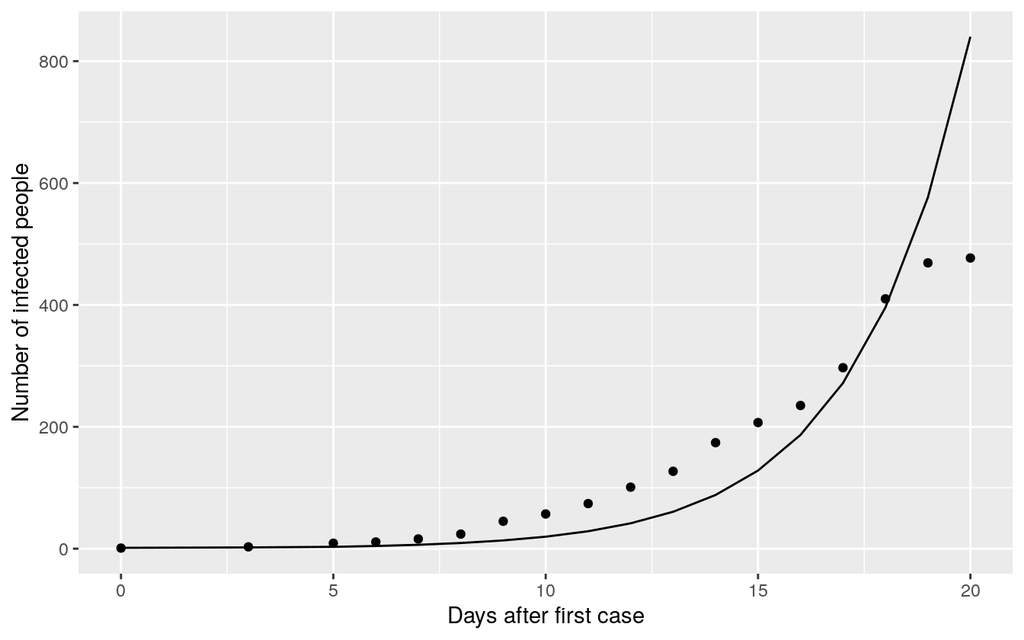

```r
ggplot(yhat[1:18,], mapping = aes(x = SIR.data$elapsed_time[1:18])) +
  #geom_ribbon(aes(ymin = -yhat$se_mean, ymax = yhat$se_mean), fill = "red", alpha = 0.3) +
  geom_line(mapping = aes(x = SIR.data$elapsed_time[1:18], y = yhat$mean[1:18])) +
  geom_point(aes(y=SIR.data$I[1:18])) +
  labs(x="Days after first case", y="Number of infected people")
```

## Try to be frequentist

Let’s try to fit the previous model with a “classic approach”. In this case we want to minimize the Residual Sum of Squares (RSS): $RSS(\beta, \gamma) = \sum_{t}(I(t)-\hat{I}(t)^2$.

```r
SIR<-function(time, state, parameters) {
  par<-as.list(c(state, parameters))
  with(par, {
    dS<--beta*I*S/N
    dI<-beta*I*S/N - gamma*I
    dR<-gamma*I
    list(c(dS, dI, dR))
  })
}

init<-c(S = SIR.data$S[1], I = SIR.data$I[1], R=0)

library(deSolve)

#RSS to optimize the parameters
RSS<-function(parameters) {
  names(parameters)<-c("beta", "gamma")
  out <-ode(y=init, times=SIR.data$elapsed_time, func=SIR, parms=parameters)
  fit<-out[,3]
  sum((SIR.data$y-fit)^2)
}

Opt<-optim(c(0.5,0.5), RSS, method="L-BFGS-B", lower=c(0,0))

#check if optim coverged--> it did
Opt$message
```

```
## [1] "CONVERGENCE: REL_REDUCTION_OF_F <= FACTR*EPSMCH"
```

```r
Opt.par<-setNames(Opt$par, c("beta", "gamma"))
Opt.par
```

```
##      beta     gamma
## 0.7697772 0.4999998
```

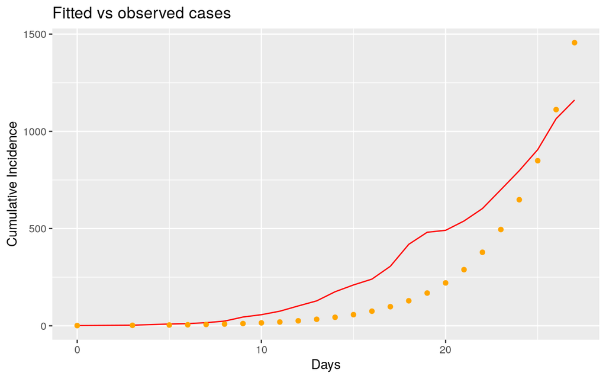

```r
fitted.cumulative.incidence<-data.frame(ode(y=init, times=SIR.data$elapsed_time, func=SIR, parms = Opt.par))

ggplot(SIR.data,aes(x=SIR.data$elapsed_time)) + geom_line(aes(y=SIR.data$y), colour="red") +
  geom_point(aes(y=fitted.cumulative.incidence$I), colour="orange")+
  labs(x = "Days",y="Cumulative Incidence", title="Fitted vs observed cases")
```

```r
R0<-as.numeric(Opt.par[1]/Opt.par[2])
R0
```

```
## [1] 1.539555
```

## References

1. [tutorial on stan for SIR model](https://mc-stan.org/users/documentation/case-studies/boarding_school_case_study.html#ref-Mihaljevic_tutorial_2016)
2. [how to deduce S-I-R numbers from our data](https://www.kaggle.com/lisphilar/covid-19-data-with-sir-model)
3. [choice of priors](https://github.com/stan-dev/stan/wiki/Prior-Choice-Recommendations)
4. [inspiration](https://github.com/saudiwin/corona_tscs/tree/master/Paper)
5. [enlightenment](https://science.sciencemag.org/content/early/2020/05/14/science.abb9789.full)